# Class 2 Break-Even Analysis and Customer Lifetime Value

Author

Affiliation

Dr. Wei Miao

UCL School of Management

Published

October 4, 2023

# 1 Overview

## 1.1 Learning Objectives

- How to conduct break-even analyses for marketing campaigns
  - Break-even quantity
  - Net present value
- Concept of customer life cycle
- Concept of and how to compute customer acquisition cost (CAC)
- Concept of and how to compute customer lifetime value (CLV)
- Practice R basic calculations and vector operations in the case study

# 2 Break-Even Analysis

## 2.1 Decisions for Marketing Managers

- Ultimate goal in the marketing process: create value and improve profitability for firms
- As any marketing activity comes with a cost, marketers need to correctly evaluate whether a campaign creates or destroys value to the company. Such analyses are called **break-even analyses (BEA)**.
- In this class, we will learn how to conduct BEA from the following 2-by-2 perspectives:
  1. Campaign-centric or customer-centric
  2. Static or dynamic

|  | **Static View** | **Dynamic View** |
| --- | --- | --- |
| **Campaign-centric** | Break-Even Quantity | Net Present Value |
| **Customer-centric** | - | Customer Lifetime Value |

## 2.2 Break-Even Quantity

- We often use **break-even analyses** to evaluate the financial feasibility of marketing investments. One commonly used way is to compute the **break-even quantity**.

**Definition**

**The break-even quantity (BEQ)** calculates the number of *incremental* units the firm needs to sell to cover the cost of the marketing campaign.

## 2.3 Break-Even Quantity: Steps and Decision Rule

- Steps to conduct break-even analysis
  - *Step 1*: Compute the BEQ based on the company’s product demand and production cost structure
  - *Step 2*: Evaluate whether the campaign can guarantee incremental sales to that quantity
- The decision rule
  - if incremental quantity sales > BEQ, the company makes money, so accept the campaign; otherwise, reject the campaign

## 2.4 Compute BEQ

Marketers often refer to the difference between the **price per unit** and **variable costs per unit** as the **contribution margin per unit**. That is,

$$Contribution Margin Per Unit = Price Per Unit - Variable Costs Per Unit$$

- **Price per unit**: retail price
- **Variable costs per unit:** Costs of goods sold (COGS)[^1] + any other variable costs
- **Marketing expenditure:** total costs of marketing investment

This gives the second formula for computing BEQ:

$$BEQ = Marketing Expenditure / Contribution Margin Per Unit$$

## 2.5 Pineapple Inc: Background

Tom Cooper, is looking to launch a series of marketing campaigns to promote its new product PinePhone 15 Pro against its competitor iPhone 15 Pro. Tom was a proud graduate from UCL MSc BA program in 2020, and he remembered learning from Marketing Analytics module that, marketers often use break-even analysis to help evaluate different types of marketing decisions.

```r
price <- 600 # retail price
quantity <- 10 # sales
COGS <- 0.6 # cost of goods sold
RD_costs <- 100 # operating and marketing costs
endorsement_fee <- 50 # endorsement
```

**Case objectives:**

- Learn an example of situation analysis for the 1st assignment
- Practice how to compute BEQ for break-even analyses
- Practice R basic computations and vector operations

## 2.6 Pineapple Inc: Key Information

**From the case:** The marketing analytics team at Pinapple Inc had applied predictive analytics models on historical sales data and predicted that the sales this year will reach **10** million units at the retail price of **£600**, without any additional marketing activities. The team had also collected the information on the Cost of Goods Sold of Pineapple 15, which is **60%**. The Research and Development (R&D) costs for PinePhone 15 is **100** million pounds.

- Open the .qmd answer sheet downloaded from Moodle. And let’s solve this case using the R basics we learned last week!

## 2.7 Pineapple Inc: BEA

- **Question 1:** Compute the contribution margin
  - Do we need to consider R&D costs?

```r
contribution_margin <- (1 - COGS) * price
contribution_margin
```

```
[1] 240
```

- **Question 2**: Based on the information at hand, should Tom approve the influencer marketing plan?

# 3 Net Present Value

## 3.1 Definition of NPV

- When the effect of the marketing campaign is expected to have a long-term effect or **when time value of money is important** to the question at hand, we need to take the future into account.

**Definition**

Net present value (NPV) is the difference between the present value of cash inflows and the present value of cash outflows over a period of time.

## 3.2 Formula of NPV

$$N P V=-I_{0}+\frac{CF_{1}}{(1+k)}+\frac{C F_{2}}{(1+k)^{2}}+\cdots+\frac{C F_{n}}{(1+k)^{n}}$$

- $I_{0}$ is the initial marketing expense
- $C F_{n}$ is the **incremental** sales in period $n$: it must be the additional sales due to the marketing campaign
- $k$ is the discount rate: reflects the value of time: the same £1 today is more valuable than £1 tomorrow
- The decision rule
  - if NPV > 0, then the marketing campaign can bring in more values to the company, accept
  - if NPV < 0, then the marketing campaign will decrease the company’s value, reject

## 3.3 Pineapple Inc: NPV Influencer Marketing I

**Question 3:** Based on the information at hand, should Tom approve the influencer marketing plan based on Net Present Value method?

1. Compute the sequence of monthly cash flows
   - Generate a sequence of incremental sales for 12 months (a vector with 12 elements)
     - Hint: use `rep()`, `c()`, and vector element-wise multiplication

```r
monthly_sales_increase_1stmonth <- 0.003
monthly_sales_increase_after <- 0.002
# incremental profit each month
monthly_incremental_sales <- c(monthly_sales_increase_1stmonth,
                     rep(monthly_sales_increase_after,11))

CF <-  monthly_incremental_sales *
                    quantity *
                    contribution_margin
```

The resulting monthly CFs are: 7.2, 4.8, 4.8, 4.8, 4.8, 4.8, 4.8, 4.8, 4.8, 4.8, 4.8, 4.8

## 3.4 Pineapple Inc: NPV Influencer Marketing II

2. Compute the sequence of discount factors
   - Generate a sequence of WACC for 12 months (a vector with 12 elements)
   - Generate a sequence of discount factor for 12 months (a vector with 12 elements)
     - Hint: use `seq()` to generate geometric sequence with patterns

```r
monthly_WACC <- 0.1/12
discount_factor <- (1/(1+monthly_WACC))^c(1:12)
```

The resulting monthly discount factors are: 0.9917355, 0.9835394, 0.975411, 0.9673497, 0.9593551, 0.9514265, 0.9435635, 0.9357654, 0.9280319, 0.9203622, 0.9127559, 0.9052124

## 3.5 Pineapple Inc: NPV Influencer Marketing III

3. Compute the NPV
   - Generate a sequence of discounted CFs for 12 months
   - Sum up all discounted CFs across the 12 months using `sum()`
   - Subtract endorsement fee from the sum to get NPV

```r
NetPresentValue <- sum(CF * discount_factor) - endorsement_fee
```

- The NPV is 6.9778057

# 4 Customer Lifetime Value

## 4.1 From Campaign-Centric to Customer-Centric Marketing

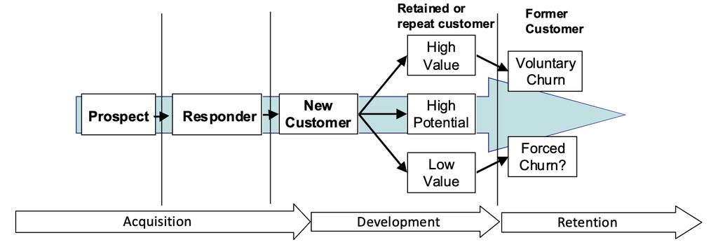

Customer Life Cycle

## 4.2 Customer Acquisition Cost

**Definition**

**Customer Acquisition Cost (CAC)** is the cost of winning a customer to purchase a product or service.

- Why should we care about CAC? Having a new customer may not always be a good thing. For example, no company would spend £500 to acquire a new customer worth £300

## 4.3 How to Acquire New Customers

- Free sampling/trials

[figure not shown]

[figure not shown]

## 4.4 How to Acquire New Customers

[figure not shown]

[figure not shown]

## 4.5 Customer Acquisition Cost: Calculation

**Definition**

When the marketing cost can be attributed to each individual customer

- CAC = (# of offers needed to acquire 1 customer) * (cost of making a marketing offer)
- CAC = (cost of making a marketing offer) / (customer response rate)
- After we study predictive analytics later in this module, we will be able to predict response rate for each individual customer and compute individual-specific CAC.

## 4.6 Customer Acquisition Cost: An Example

A new Bubble Tea shop in Canary Wharf is contemplating whether or not to attract new customers by sending ads leaflets to nearby residents.

The cost of sending a leaflet, which includes production and labor costs, is **£0.5**.

1. randomly sending out leaflets
   - expected response rate of **1%**
2. using names purchased from a marketing agency
   - each name costs **£0.2**
   - expected response rate of **4%** by analyzing the buying behavior and demographics of current customers

Compute the CAC for each choice.

```r
cost_per_random_offer <- 0.5
response_rate_random_offer <- 0.01
# Following the formula in the previous slide
CAC_random_offer <- cost_per_random_offer / response_rate_random_offer
CAC_random_offer
```

```
[1] 50
```

```r
cost_per_targeted_offer <- 0.5 + 0.2
response_rate_targeted_offer <- 0.04
CAC_targeted_offer <- cost_per_targeted_offer/response_rate_targeted_offer
CAC_targeted_offer
```

```
[1] 17.5
```

**Tips for assignment 1**

The cost structures for sending out offers are different from the simple example here, but the logic of calculation is the same. Think carefully about how to compute the cost per offer (the components) in the assignment.

## 4.7 Customer Lifetime Value (CLV)

**Definition**

Customer lifetime value (CLV or LTV) is the total worth to a business of a customer over the whole period of their relationship.

- The underlying idea of CLV is essentially NPV, but at the customer level.
  - Think of acquiring a new customer as an investment in an “asset” that can generate future cash flows

## 4.8 CLV: Calculation

$$\mathrm{CLV} = - CAC + \sum_{t=1}^{N} \frac{CF_t * r^{(t-1)}}{(1+k)^{t}},
where \space CF_t = M_t - c_t$$

- $r$ is the average annual retention rate; $r^{(t-1)}$ is the cumulative retention rate in year $t$
- $N$ is the number of years over which the relationship is calculated
- $M_{t}$ is the margin the customer generates in year $t$
- $c_{t}$ is the expected cost of marketing communications or promotions targeted to the customer in year $t$
- $k$ is the rate for discounting future cash flows

## 4.9 Retention Rate

**Definition**

The churn rate, also known as the rate of attrition or customer churn, is the rate at which customers stop doing business with an entity.

- retention rate = 1 - churn rate
- **How to compute *individual* churn rate**: machine learning models to predict the churn rate of an individual customer (Week 4)

## 4.10 Number of Years of Customer Relationship

- If we assume **infinite** customer economic life, we can simplify the formula into the following using the property of geometric sequence.

$$C L V_{N} = \sum_{t=1}^{N} \frac{g r^{(t-1)}}{(1+k)^{t}} => C L V_{N}=\mathrm{g} \cdot \frac{1-\left(\frac{r}{1+k}\right)^{N}}{1+k-r} =>
C L V_{\infty}=\frac{g}{(1+k-r)}$$

- However, most of the time, we are more comfortable to assume **finite** customer economic life; we need to decide on a cutoff date for CLV calculation
  - Rule 1: until the year when the $g = M-c$ becomes negative
  - Rule 2: industry’s average customer lifespan

## 4.11 After-class

- Review the coding practice in today’s class.
- We will solve Harvard Business Case: **Customer Lifetime Social Value.** Remember to read the case background before next week’s class.
  - You can try to solve the case on your own using what we’ve covered today.
- Optional readings are for alternative ways to compute CLV in the industry.

## Footnotes

[^1]: Material and production labor costs for producing a unit of product; often represented in **percentage terms,** e.g., COGS of 60% means the costs are 60% of retail prices.